# STT 301: Take-home exam

Rellika Kisyula

10/16/2018

## Required packages: ggplot2

```r
# load required package
library(ggplot2)
library(dplyr)
library(tidyr)
```

## Data

The data are the results of a chemical analysis of wines grown in the same region in Italy but derived from three different cultivars (origins). The analysis determined the quantities of 13 constituents found in each of the three types of wines. The data is from the UCI Machine Learning Repository (https://archive.ics.uci.edu/ml/datasets/wine). The data set has 14 columns.

1. Origin
2. Alcohol
3. Malic acid
4. Ash
5. Alcalinity of ash
6. Magnesium
7. Total phenols
8. Flavanoids
9. Nonflavanoid phenols
10. Proanthocyanins
11. Color intensity
12. Hue
13. OD280/OD315 of diluted wines
14. Proline

Copy the below code into an R chunk in your .Rmd file.

```r
# read in the wine data
URL <- "https://archive.ics.uci.edu/ml/machine-learning-databases/wine/wine.data"
wine <- read.csv(URL, stringsAsFactors = F, header = F)

# assign column names
colnames(wine) <- c("origin", "alcohol", "acid",
                    "ash", "alcalinity", "magnesium",
                    "phenols", "flavanoids", "nonflavanoid",
                    "proanthocyanins", "color.int", "hue",
                    "od", "proline")

# change origin variable to a factor
wine$origin <- as.factor(wine$origin)

str(wine)
```

```
## 'data.frame':    178 obs. of  14 variables:
##  $ origin         : Factor w/ 3 levels "1","2","3": 1 1 1 1 1 1 1 1 1 1 ...
##  $ alcohol        : num  14.2 13.2 13.2 14.4 13.2 ...
##  $ acid           : num  1.71 1.78 2.36 1.95 2.59 1.76 1.87 2.15 1.64 1.35 ...
##  $ ash            : num  2.43 2.14 2.67 2.5 2.87 2.45 2.45 2.61 2.17 2.27 ...
##  $ alcalinity     : num  15.6 11.2 18.6 16.8 21 15.2 14.6 17.6 14 16 ...
##  $ magnesium      : int  127 100 101 113 118 112 96 121 97 98 ...
##  $ phenols        : num  2.8 2.65 2.8 3.85 2.8 3.27 2.5 2.6 2.8 2.98 ...
##  $ flavanoids     : num  3.06 2.76 3.24 3.49 2.69 3.39 2.52 2.51 2.98 3.15 ...
##  $ nonflavanoid   : num  0.28 0.26 0.3 0.24 0.39 0.34 0.3 0.31 0.29 0.22 ...
##  $ proanthocyanins: num  2.29 1.28 2.81 2.18 1.82 1.97 1.98 1.25 1.98 1.85 ...
##  $ color.int      : num  5.64 4.38 5.68 7.8 4.32 6.75 5.25 5.05 5.2 7.22 ...
##  $ hue            : num  1.04 1.05 1.03 0.86 1.04 1.05 1.02 1.06 1.08 1.01 ...
##  $ od             : num  3.92 3.4 3.17 3.45 2.93 2.85 3.58 3.58 2.85 3.55 ...
##  $ proline        : int  1065 1050 1185 1480 735 1450 1290 1295 1045 1045 ...
```

## Question 1

Use the `wine` data frame to produce each of the plots below using `ggplot`. Your plot must look exactly the same to earn full credit. Details are provided when not obvious.

## Plot 1 (10 points)

Details: include the chunk option: `fig.width=9, fig.height=6` color of boxes is purple transparancy is 0.4

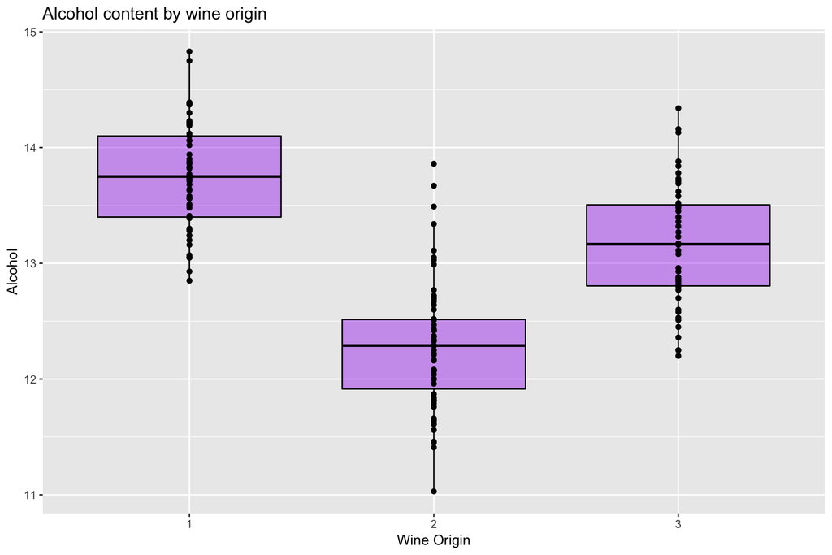

```r
ggplot(data = wine,
       mapping=aes(x = origin, y = alcohol)) +
    geom_boxplot(color = "black", fill = "purple", alpha=0.4) +
    labs(x="Wine Origin", y="Alcohol", title="Alcohol content by wine origin") +
    geom_point(aes(y=alcohol), position = position_dodge(width=0.75))
```

## Plot 2 (10 points)

Details: include the chunk option: `fig.width=12, fig.height=6` transparancy is 0.5

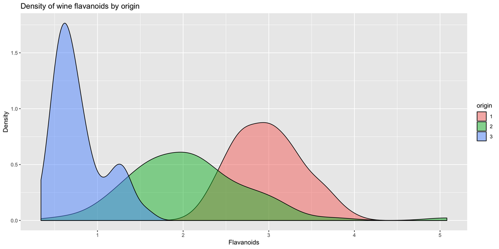

```r
ggplot(data = wine, aes(x = flavanoids, fill = origin)) +
  geom_density(alpha = 0.50) +
  labs(x = "Flavanoids", y = "Density",
       title = "Density of wine flavanoids by origin")
```

## Plot 3 (10 points)

Details: include the chunk option: `fig.width=12, fig.height=6` size is 3 to change color scale: `scale_color_gradient(low = "blue", high = "red")` theme is bw

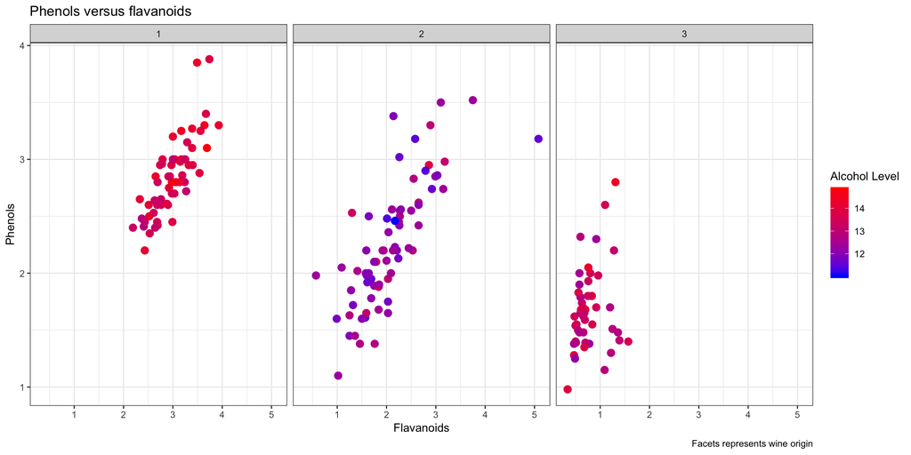

```r
ggplot(data=wine, aes(x=flavanoids, y=phenols, color = alcohol)) +
    geom_point(size=3) + facet_wrap(~origin) +
    theme_bw() +
    scale_color_gradient(low = "blue", high = "red") +
    labs(name = "New Legend Title",
         title= "Phenols versus flavanoids",
         x= "Flavanoids",
         y= "Phenols",
         color='Alcohol Level',
         caption = "Facets represents wine origin")
```

## Plot 4 (10 points)

Use `wine` to create an original plot with `ggplot`. You may use additional packages. If you do use additional packages, be sure to load them with the library function in the chunk where you have `library(ggplot2)`.

```r
head(wine)
```

```
##   origin alcohol acid  ash alcalinity magnesium phenols flavanoids
## 1      1   14.23 1.71 2.43       15.6       127    2.80       3.06
## 2      1   13.20 1.78 2.14       11.2       100    2.65       2.76
## 3      1   13.16 2.36 2.67       18.6       101    2.80       3.24
## 4      1   14.37 1.95 2.50       16.8       113    3.85       3.49
## 5      1   13.24 2.59 2.87       21.0       118    2.80       2.69
## 6      1   14.20 1.76 2.45       15.2       112    3.27       3.39
##   nonflavanoid proanthocyanins color.int  hue   od proline
## 1         0.28            2.29      5.64 1.04 3.92    1065
## 2         0.26            1.28      4.38 1.05 3.40    1050
## 3         0.30            2.81      5.68 1.03 3.17    1185
## 4         0.24            2.18      7.80 0.86 3.45    1480
## 5         0.39            1.82      4.32 1.04 2.93     735
## 6         0.34            1.97      6.75 1.05 2.85    1450
```

**I removed the last column *proline* to reduce the outliers in the bar graph**

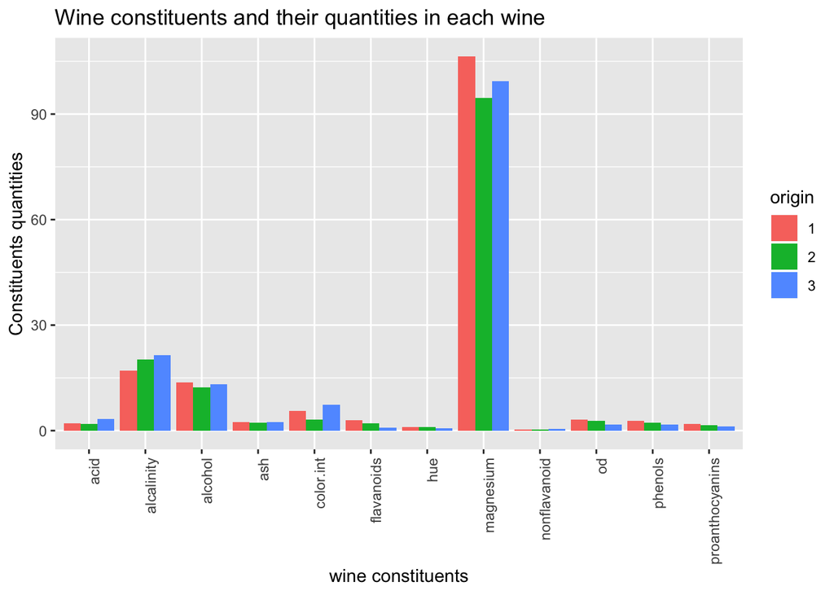

```r
wine %>%
    group_by(origin=factor(origin)) %>%
    summarise_all(funs(mean)) %>%
    gather(constituents, quantities, -origin, -proline) %>%
    ggplot(., aes(x=constituents, y=quantities, fill=origin))+
    geom_bar(stat='identity', position='dodge') +
    theme(axis.text.x = element_text(angle = 90, hjust = 1)) +
    labs(x= "wine constituents",
         y= "Constituents quantities",
         title = "Wine constituents and their quantities in each wine")
```

## Question 2 (20 points)

Write a function named `df.numeric.summary` that takes any data frame as an input, and for each numeric variable in the data frame, the function returns the variable’s mean, median, and inter-quartile range in the form of a list. The list should have the names of the corresponding variables.

Below are two examples for you to see the function in action.

```r
df.numeric.summary <- function(df) {
   df.numeric <- df[,sapply(df, is.numeric)]
   lyst <- list()
   for (variable in names(df.numeric)) {
       lyst[[variable]] <-
           c(c("Mean", "Median", "IQR"),
            c(mean(df.numeric[[variable]], na.rm = T),
            median(df.numeric[[variable]], na.rm = T),
            IQR(df.numeric[[variable]], na.rm = T)))
   }
   return(lyst)
}
```

```r
df.numeric.summary(wine[, 1:4])
```

```
## $alcohol
## [1] "Mean"             "Median"           "IQR"
## [4] "13.0006179775281" "13.05"            "1.315"
##
## $acid
## [1] "Mean"             "Median"           "IQR"
## [4] "2.33634831460674" "1.865"            "1.48"
##
## $ash
## [1] "Mean"             "Median"           "IQR"
## [4] "2.36651685393258" "2.36"             "0.3475"
```

```r
df.numeric.summary(mtcars[, 1:4])
```

```
## $mpg
## [1] "Mean"      "Median"    "IQR"       "20.090625" "19.2"      "7.375"
##
## $cyl
## [1] "Mean"   "Median" "IQR"    "6.1875" "6"      "4"
##
## $disp
## [1] "Mean"       "Median"     "IQR"        "230.721875" "196.3"
## [6] "205.175"
##
## $hp
## [1] "Mean"     "Median"   "IQR"      "146.6875" "123"      "83.5"
```